# Data Visualization

Now we aim to examine the frequency of crimes that took place in the year 2016 and explore any possible patterns or trends in the data. We intend to visualize the number of crimes that occurred in the given year and investigate whether there are any seasonal or other variations in the data.

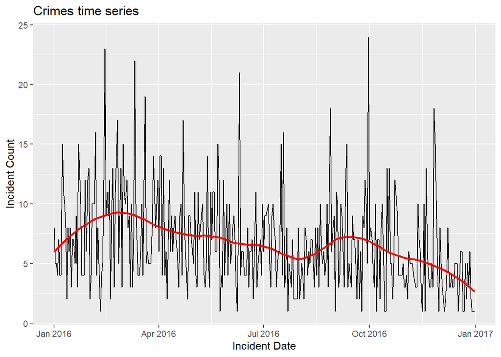

```r
incDateDf <- dvDataFrame %>%
  group_by(INCIDENT_DATE) %>%
  summarize(count=n())
mean_count <- mean(incDateDf$count)
ggplot(incDateDf, aes(x = INCIDENT_DATE, y = count)) +
  labs(title = "Crimes time series", y = "Incident Count", x = "Incident Date")+
  geom_line()+
  stat_smooth(aes(y = count), se = FALSE, method = "auto", span = 0.3, color = "red")
```

Based on the depicted time series plot, it can be observed that the occurrence of crimes has shown a gradual decline over the course of the year, with higher frequencies recorded at the start of the year, followed by a downward trend towards the end of the year.

**Marijuana incidents month wise distribution**

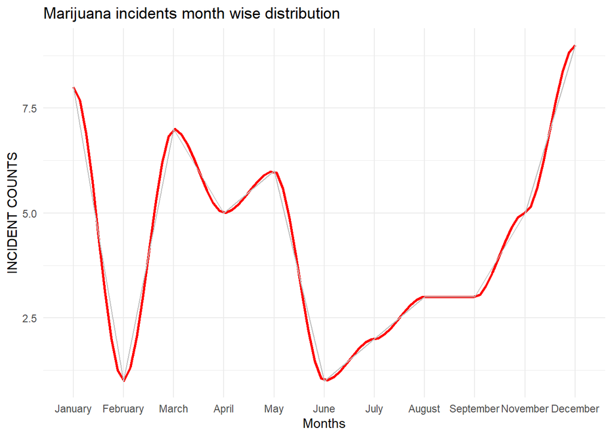

```r
incMonthCount_data <- dvDataFrame %>%
  filter(SUBJECT_DESCRIPTION == "Marijuana") %>%
  group_by(INCIDENT_MONTH) %>%
  summarise(count=n())
ggplot(data = incMonthCount_data, aes(factor(INCIDENT_MONTH, month.name), count, group = 1)) +
  geom_smooth(method = "loess", color = "red", span = 1/5) +
  geom_line(size = 0.5, col = "gray") +
  labs(x = "Months", y = "INCIDENT COUNTS", title = "Marijuana incidents month wise distribution")+
  theme_minimal()
```

**Conclusion:**

Overall, the insights suggest potential biases or discrimination in law enforcement practices against Black and Hispanic individuals, especially males. The hiring and retention practices of police departments may also contribute to these biases. The trends in crime occurrence and marijuana cases can provide valuable information for law enforcement agencies to plan and allocate resources effectively.